# Primer informe - Descriptivo

Carlos Santana Flores

# Gasto Público por Estudiante en Educación Básica: Un Estudio Regional en el Perú (2009-2022)

El presente informe estadístico tiene como objetivo **analizar el gasto anual en educación básica** –que abarca los niveles de inicial, primaria y secundaria– que el gobierno central de la República del Perú ha venido asumiendo a lo largo del período 2009-2022. Este análisis se fundamenta en una base de datos organizada por departamentos del país y se sustenta en información proveniente del Ministerio de Economía y Finanzas (MEF), con el respaldo metodológico y las cifras recopiladas por el Instituto Nacional de Estadística e Informática [INEI - Publicaciones](https://www.inei.gob.pe/estadisticas/indice-tematico/sociales/). De esta manera, se busca ofrecer una visión integral de la evolución del gasto público por estudiante de educación básica, identificando tendencias, brechas y posibles factores que hayan influido en su comportamiento a lo largo del tiempo.

[figure not shown]

La elección del período 2009-2022 permite evaluar dinámicas de corto y mediano plazo, al tiempo que la desagregación por departamentos posibilita examinar las disparidades regionales existentes. La información obtenida, producto del procesamiento y sistematización de datos oficiales, facilitará no solo la comprensión del panorama actual del financiamiento educativo, sino también la formulación de recomendaciones y lineamientos para la toma de decisiones informadas en el sector. Así, este estudio busca contribuir al debate sobre la inversión en educación, en aras de optimizar el uso de los recursos públicos y promover una enseñanza de mayor calidad en el territorio nacional.

### Información recopilada

La base de datos se obtuvo del portal de publicaciones de la página web de la INEI el formato presentado es un *data panel* con extensión EXCEL que consta de variables como los departamentos del Perú, nivel educativo y el gasto anual que incurre le gobierno central por el año escolar de un estudiante. A continuación se muestra una parte de la base de datos.

#### Data

| departamento | nivel_educativo | x2009 | x2010 | x2011 | x2012 | x2013 | x2014 | x2015 | x2016 | x2017 | x2018 | x2019 | x2020 | x2021 | x2022 |
| --- | --- | --- | --- | --- | --- | --- | --- | --- | --- | --- | --- | --- | --- | --- | --- |
| Amazonas | Inicial | 1129.047 | 1218.488 | 1430 | 1593 | 2011 | 3139.000 | 4307.000 | 3853 | 3930.767 | 3340.425 | 3940.57 | 3397.532 | 3904.190 | 3397 |
| Amazonas | Primaria | 1499.279 | 1496.123 | 1725 | 2025 | 1946 | 2419.857 | 3891.436 | 2938 | 3328.167 | 3641.507 | 3676.00 | 3682.823 | 3945.389 | 4069 |
| Amazonas | Secundaria | 1581.995 | 1494.883 | 1711 | 2202 | 2464 | 2757.000 | 3207.941 | 3736 | 4156.577 | 4595.005 | 5005.00 | 5309.485 | 4978.155 | 4844 |
| Áncash | Inicial | 1589.210 | 1633.100 | 1872 | 2368 | 2466 | 2522.000 | 2565.000 | 2503 | 3242.962 | 3812.868 | 3769.00 | 3607.640 | 5150.662 | 5457 |
| Áncash | Primaria | 1981.416 | 1972.605 | 2195 | 2530 | 2515 | 2802.000 | 2711.803 | 2642 | 3459.523 | 3764.425 | 3912.00 | 3934.197 | 5105.574 | 5695 |
| Áncash | Secundaria | 2338.007 | 2416.415 | 2131 | 2728 | 2657 | 2838.000 | 3025.651 | 3342 | 4673.373 | 4938.953 | 5251.00 | 5189.218 | 7556.212 | 7732 |

#### Estructura de los datos y algunas características descriptivas

| **Variable** | **Stats / Values** | **Freqs (% of Valid)** | **Graph** | **Missing** |
| --- | --- | --- | --- | --- |
| departamento [character] | 1. Amazonas 2. Áncash 3. Apurímac 4. Arequipa 5. Ayacucho 6. Cajamarca 7. Callao 8. Cusco 9. Huancavelica 10. Huánuco [ 16 others ] | 3 ( 3.8% ) 3 ( 3.8% ) 3 ( 3.8% ) 3 ( 3.8% ) 3 ( 3.8% ) 3 ( 3.8% ) 3 ( 3.8% ) 3 ( 3.8% ) 3 ( 3.8% ) 3 ( 3.8% ) 48 ( 61.5% ) |  | 0 (0.0%) |
| nivel_educativo [character] | 1. Inicial 2. Primaria 3. Secundaria | 26 ( 33.3% ) 26 ( 33.3% ) 26 ( 33.3% ) |  | 0 (0.0%) |
| x2009 [numeric] | Mean (sd) : 1605.3 (630.1) min ≤ med ≤ max: 786.3 ≤ 1499 ≤ 6044.1 IQR (CV) : 381.4 (0.4) | 78 distinct values |  | 0 (0.0%) |
| x2010 [numeric] | Mean (sd) : 1693.2 (642.8) min ≤ med ≤ max: 899 ≤ 1531.1 ≤ 4895 IQR (CV) : 467.6 (0.4) | 78 distinct values |  | 0 (0.0%) |
| x2011 [numeric] | Mean (sd) : 1838.6 (449.9) min ≤ med ≤ max: 1112 ≤ 1792 ≤ 3489 IQR (CV) : 473.2 (0.2) | 78 distinct values |  | 0 (0.0%) |
| x2012 [numeric] | Mean (sd) : 2197.7 (613.7) min ≤ med ≤ max: 1096 ≤ 2153.5 ≤ 4185 IQR (CV) : 641.2 (0.3) | 77 distinct values |  | 0 (0.0%) |
| x2013 [numeric] | Mean (sd) : 2433.2 (754.2) min ≤ med ≤ max: 1295 ≤ 2388.5 ≤ 5549 IQR (CV) : 701.5 (0.3) | 75 distinct values |  | 0 (0.0%) |
| x2014 [numeric] | Mean (sd) : 2788 (833.3) min ≤ med ≤ max: 1417 ≤ 2608 ≤ 5146 IQR (CV) : 1123.5 (0.3) | 76 distinct values |  | 0 (0.0%) |
| x2015 [numeric] | Mean (sd) : 3154.8 (938.1) min ≤ med ≤ max: 1656.6 ≤ 3069.9 ≤ 5856.3 IQR (CV) : 1350.7 (0.3) | 78 distinct values |  | 0 (0.0%) |
| x2016 [numeric] | Mean (sd) : 3139.4 (1036.3) min ≤ med ≤ max: 1595 ≤ 2982 ≤ 5992 IQR (CV) : 1374.8 (0.3) | 77 distinct values |  | 0 (0.0%) |
| x2017 [numeric] | Mean (sd) : 3570.9 (1056.3) min ≤ med ≤ max: 1814.9 ≤ 3393.8 ≤ 6653.4 IQR (CV) : 1537.3 (0.3) | 78 distinct values |  | 0 (0.0%) |
| x2018 [numeric] | Mean (sd) : 3720.4 (1136.9) min ≤ med ≤ max: 1993.8 ≤ 3601.6 ≤ 7172.4 IQR (CV) : 1638.1 (0.3) | 78 distinct values |  | 0 (0.0%) |
| x2019 [numeric] | Mean (sd) : 3875.9 (1142.4) min ≤ med ≤ max: 1770 ≤ 3732.5 ≤ 6652 IQR (CV) : 1882.8 (0.3) | 77 distinct values |  | 0 (0.0%) |
| x2020 [numeric] | Mean (sd) : 3727.1 (1145) min ≤ med ≤ max: 1767.5 ≤ 3595.1 ≤ 7264.6 IQR (CV) : 1551.2 (0.3) | 78 distinct values |  | 0 (0.0%) |
| x2021 [numeric] | Mean (sd) : 4131.9 (1281.5) min ≤ med ≤ max: 1882.3 ≤ 3924.8 ≤ 7711 IQR (CV) : 1426 (0.3) | 78 distinct values |  | 0 (0.0%) |
| x2022 [numeric] | Mean (sd) : 4301.9 (1483.3) min ≤ med ≤ max: 2246 ≤ 4048.5 ≤ 9921 IQR (CV) : 1764.5 (0.3) | 78 distinct values |  | 0 (0.0%) |

### Análisis gráfico de comportamiento temporal del gasto anual de un estudiante por nivel educativo

#### Educación Inicial

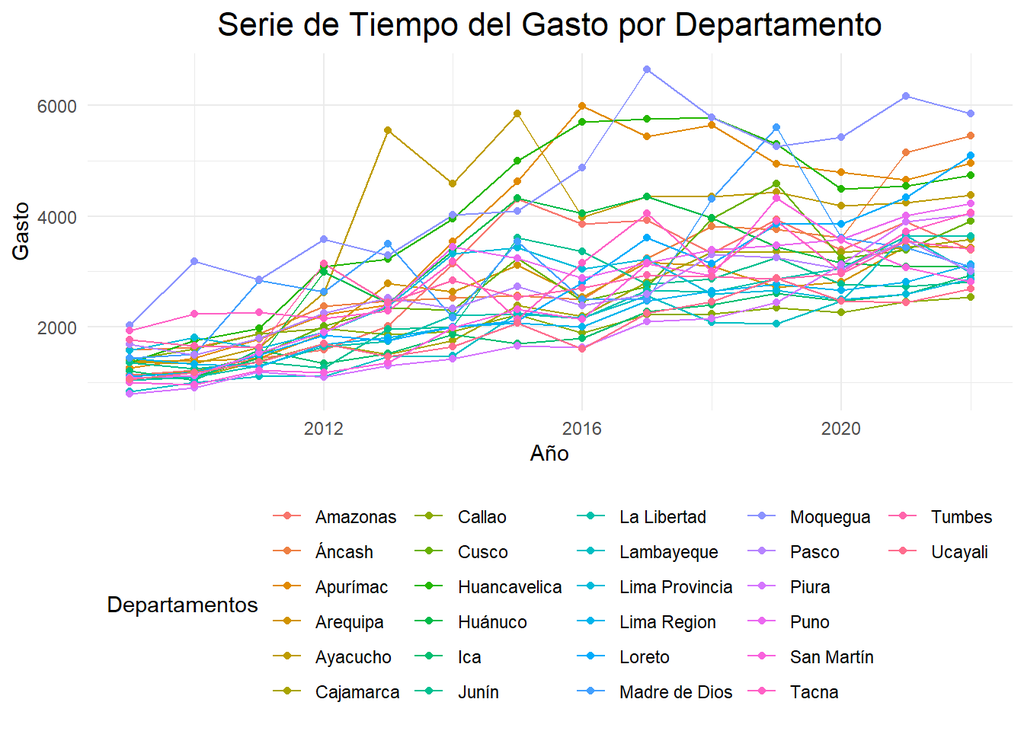

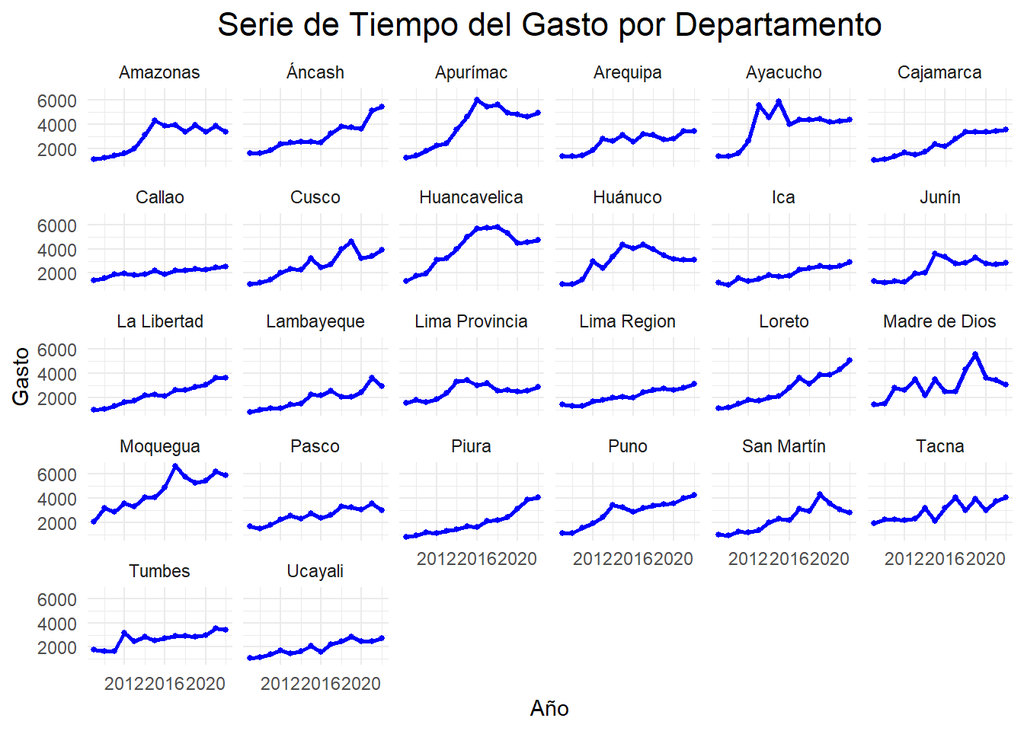

#### Educación Primaria

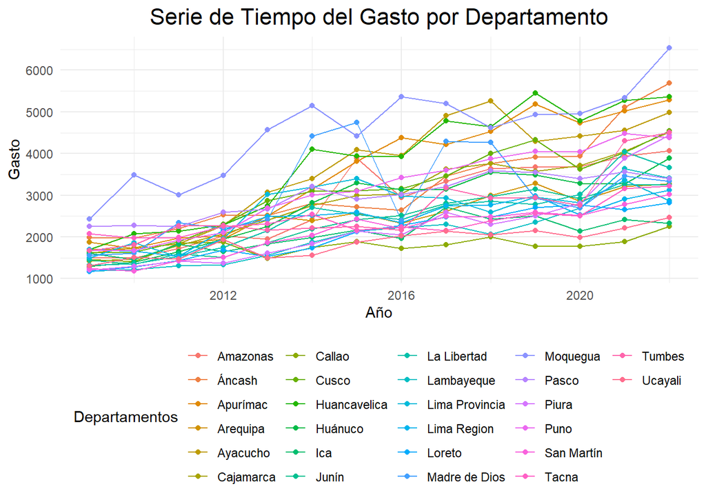

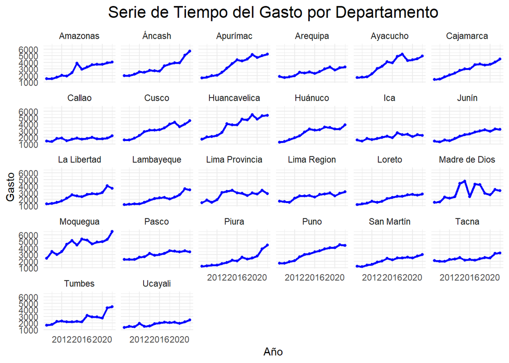

#### Educación Secundaria

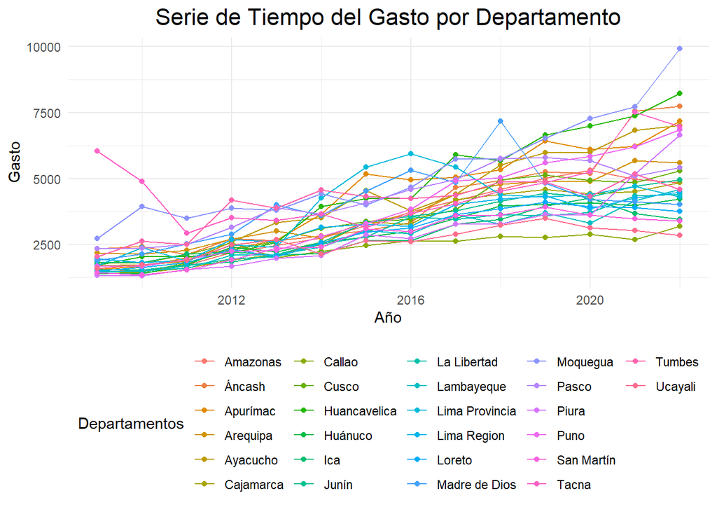

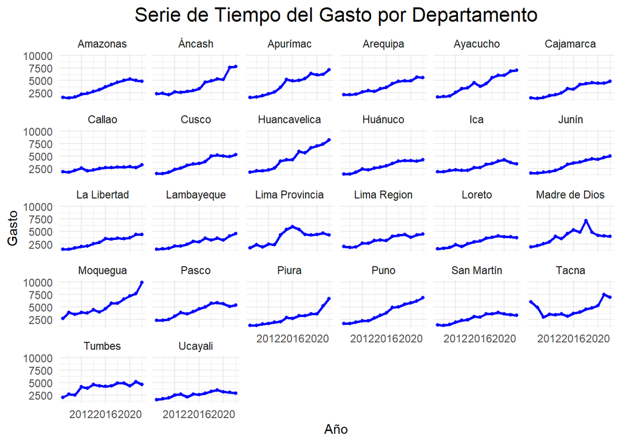

### Gasto anual de un estudiante de educación básica en el 2022

#### Medidas descriptivas

|  | vars | n | mean | sd | median | trimmed | mad | min | max | range | skew | kurtosis | se |
| --- | --- | --- | --- | --- | --- | --- | --- | --- | --- | --- | --- | --- | --- |
| Gasto Inicial | 1 | 26 | 3698.69 | 916.62 | 3424 | 3619.14 | 857.68 | 2535 | 5862 | 3327 | 0.78 | -0.53 | 179.76 |
| Gasto Primaria | 2 | 26 | 3869.58 | 1098.02 | 3533 | 3809.41 | 1157.91 | 2246 | 6535 | 4289 | 0.54 | -0.54 | 215.34 |
| Gasto Secundaria | 3 | 26 | 5337.31 | 1744.48 | 4848 | 5208.00 | 1424.78 | 2852 | 9921 | 7069 | 0.76 | -0.18 | 342.12 |

#### Gráficos

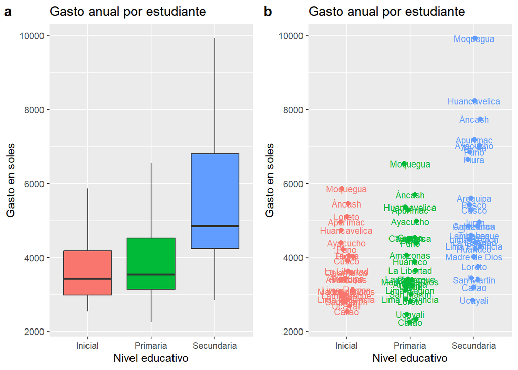

### Gasto anual por alumno en educación inicial para el 2022

#### Cálculos previos

| Cálculos Previos | Valor |
| --- | --- |
| Máximo | 5862.0 |
| Mínimo | 2535.0 |
| Rango | 3327.0 |
| N_intervalos | 6.0 |
| Ancho sin redondeo | 554.5 |
| Ancho Intervalo | 555.0 |

#### Distribución de departamentos según el gasto incurrido en la educación inicial

| Gasto | fi | pi(%) | Fi | Pi(%) |
| --- | --- | --- | --- | --- |
| (2535, 3090] | 10 | 38.5 | 10 | 38.5 |
| (3090, 3645] | 6 | 23.1 | 16 | 61.6 |
| (3645, 4200] | 3 | 11.5 | 19 | 73.1 |
| (4200, 4755] | 3 | 11.5 | 22 | 84.6 |
| (4755, 5310] | 2 | 7.7 | 24 | 92.3 |
| (5310, 5865] | 2 | 7.7 | 26 | 100.0 |

#### Histograma

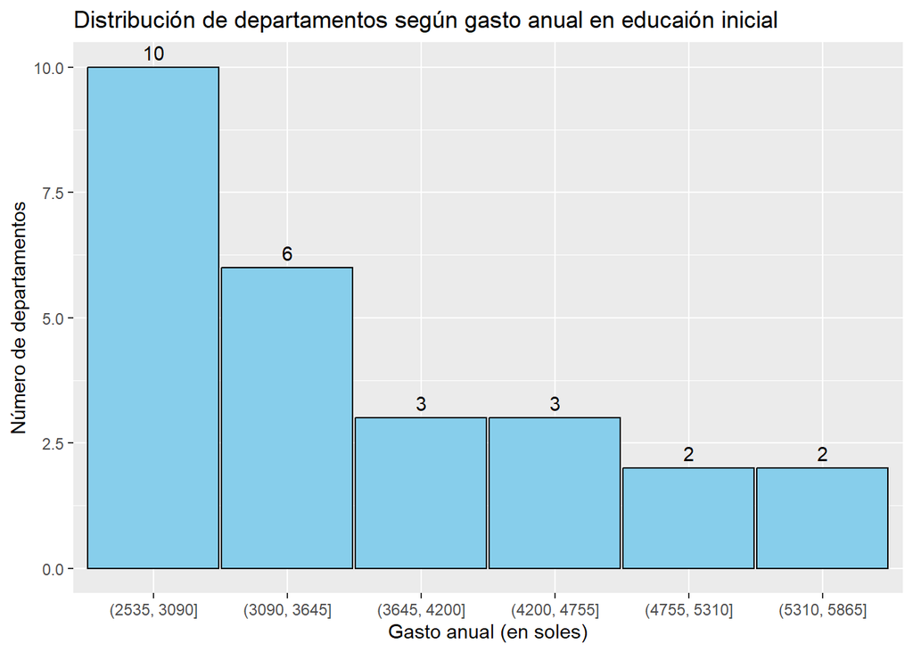

### Probabilidades con eventos

#### Eventos

- I: Inicial
- P: Primaria
- S: Secundaria
- M: Masculino
- F: Femenino

#### A partir de una tabla de doble entrada

Distribución de estudiantes de educación inicial según nivel educativo y sexo

|  | Masculino | Femenino | Total |
| --- | --- | --- | --- |
| Inicial | 12 | 14 | 26 |
| Primaria | 15 | 16 | 31 |
| Secundaria | 17 | 22 | 39 |
| Total | 44 | 52 | 96 |

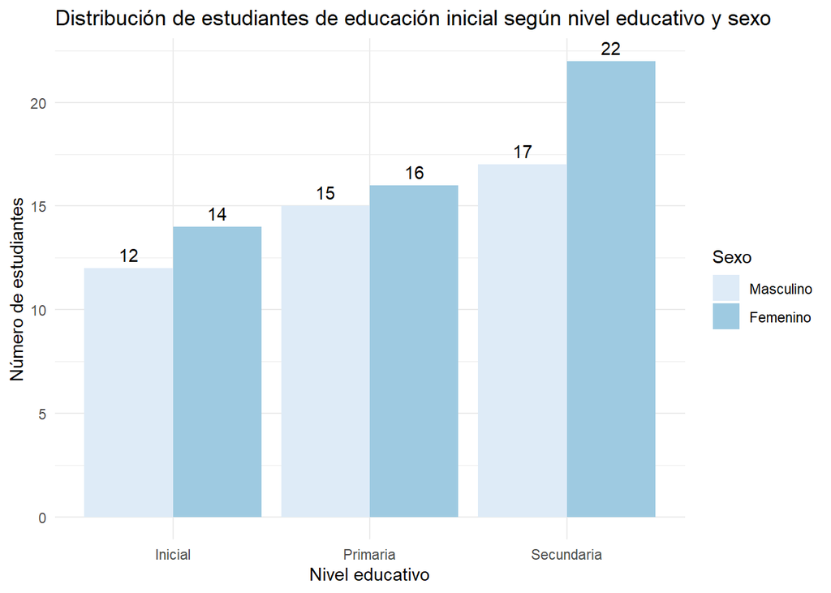

Si se selecciona a un estudiante al azar, cuál es la probabilidad de que sea de educación inicial y de sexo femenino
$$P(I n F) = 14 / 96 = 0.146$$

#### A partir de una tabla de doble entrada en valores porcentuales

Distribución porcentual de estudiantes de educación inicial según nivel educativo y sexo

|  | Masculino | Femenino | Total |
| --- | --- | --- | --- |
| Inicial | 12.5 | 14.6 | 27.1 |
| Primaria | 15.6 | 16.7 | 32.3 |
| Secundaria | 17.7 | 22.9 | 40.6 |
| Total | 45.8 | 54.2 | 100.0 |

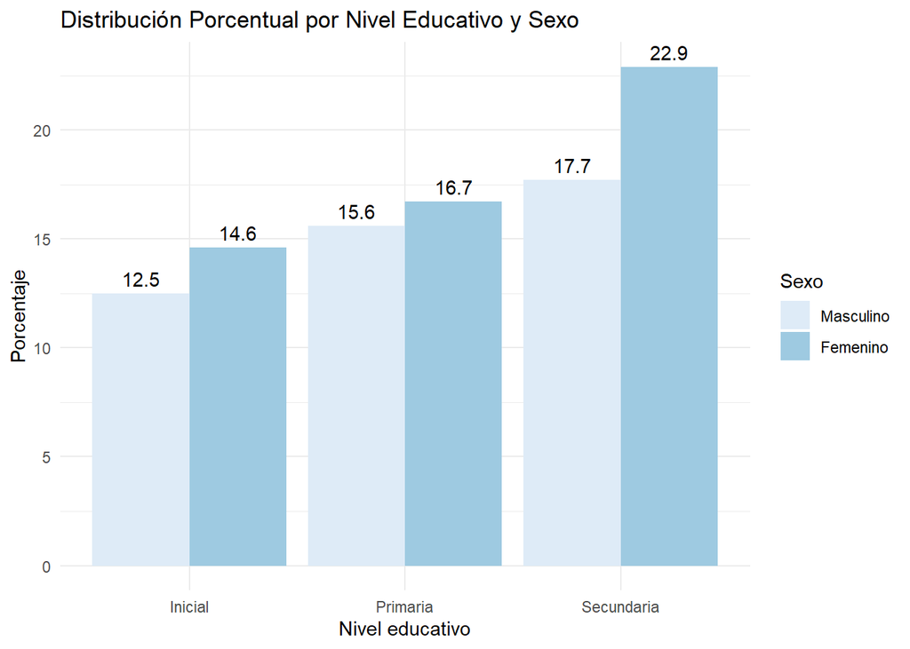

Si se selecciona a un estudiante al azar, cuál es la probabilidad de que sea de educación inicial y de sexo femenino
$$P(I n F) = 0.146$$

#### A partir de una tabla de doble entrada respecto a las filas

Distribución porcentual de estudiantes de educación inicial según sexo por nivel educativo

|  | Masculino | Femenino | Total |
| --- | --- | --- | --- |
| Inicial | 46.2 | 53.8 | 100 |
| Primaria | 48.4 | 51.6 | 100 |
| Secundaria | 43.6 | 56.4 | 100 |

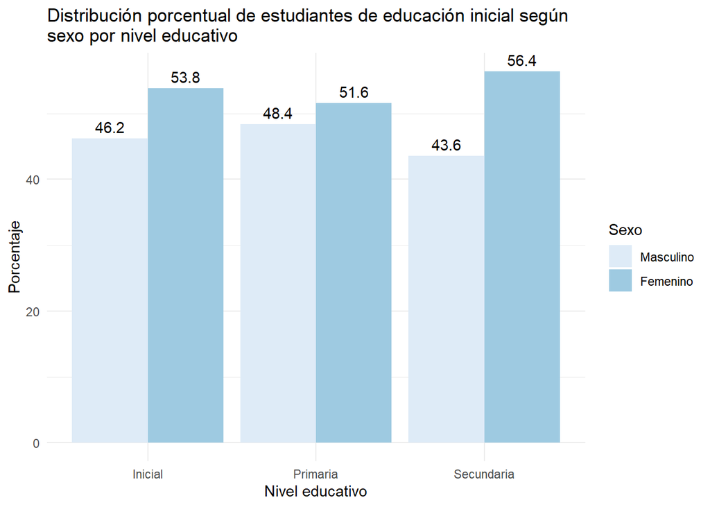

Si se selecciona a un estudiante al azar de educación inicial, cuál es la probabilidad de que sea del sexo femenino
$$P(F / I) = 0.538$$

#### A partir de una tabla de doble entrada respecto a las columnas

Distribución porcentual de estudiantes de educación inicial según nivel educativo por sexo

|  | Masculino | Femenino |
| --- | --- | --- |
| Inicial | 27.3 | 26.9 |
| Primaria | 34.1 | 30.8 |
| Secundaria | 38.6 | 42.3 |
| Total | 100.0 | 100.0 |

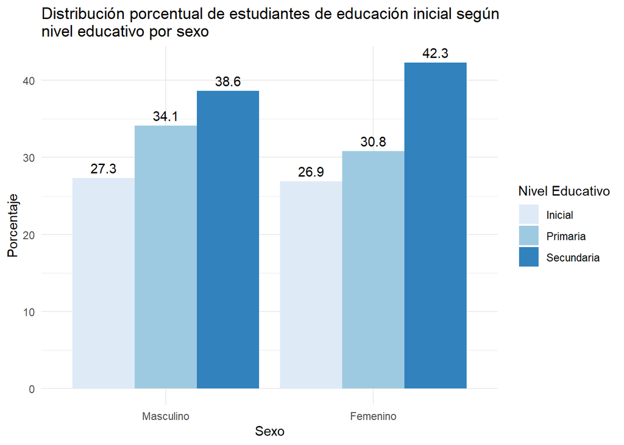

Si se selecciona a un estudiante al azar del sexo femenino, cuál es la probabilidad de que sea de educación inicial
$$P(I / F) = 0.269$$

### Probabilidad para variable aleatoria

#### Caso 1 - Distribución normal

El gasto anual en un alumno de educación secundaria que incurre el estado tiene una distribución normal cou una media de 3500 soles y un desviación estándar de 58 soles. Si se selecciona a un alumno al azar cuál la probabilidad de que el gasto anual sea mayor a 3525 soles.

```
## [1] 0.3332216
```

#### Caso 2 - Distribución binomial

Se sabe que el departamento de Moquegua es el que invierte más en sus estudiantes de educación escolar y que la probabilidad de que un estudiante desapruebe el año escolar es del 5%. Si se selecciona una muestra de 30 alumnos, cuál es la probabilidad que a lo más hayan desaprobado 2 estudiantes.

```
## [1] 0.8121788
```

#### Caso 3 - Distribución de Poisson

En el departamento de Ucayali la cantidad de estudiantes ausentes en un día de clase en una unidad educativa sigue un proceso de Poisson. Si se sabe que la cantidad promedio de estudiantes ausentes en un día de clase es de cuatro estudiantes. Cuál es la probabilidad de que en un dia de clase falten más de cinco estudiantes en un dia de clase.

```
## [1] 0.2148696
```

### Tamaño de muestra

```
## [1] 39
```

### Intervalo de confianza para la media

Se desea estimar el tiempo promedio de traslado de casa al colegio de estudiantes de Áncash a un nivel de confianza del 96%. Si el tiempo promedio de traslado de casa al colegio supera los 30 minutos se optará por darle una bicicleta a cada estudiante.

```
##
##  One Sample t-test
##
## data:  tiempos
## t = 42.885, df = 27, p-value < 0.00000000000000022
## alternative hypothesis: true mean is not equal to 0
## 96 percent confidence interval:
##  31.12176 34.41960
## sample estimates:
## mean of x
##  32.77068
```

### Intervalo de confianza para una proporción

Se desea estimar el porcentaje de deserciones escolares en un año escolar en el departamento de Apurimac a un nivel de confianza de 95%. El año anterior, de una muestra piloto de 120 estudiantes se encontró que 10 estudiantes habían desertado.

```
## Intervalo de confianza del 95% para la proporción: 0.03388262 a 0.132784
```